# White wine study

# Multivariate Plots Section

> Now we are going to progress to the mutlivariate analysis section. Here I hope to find a combination of chemical properties that will answer our original question of “What chemical properties determine quality?” with more conviction that what I have been able to supply thus far. Given that the bivaraite analysis yielded only weak correlation values it leads me to believe that a combination of chemical properties may be the right place to find a meaningful correlation value.

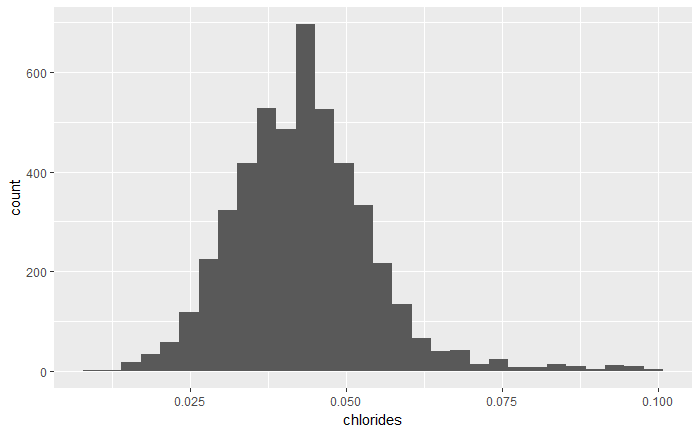

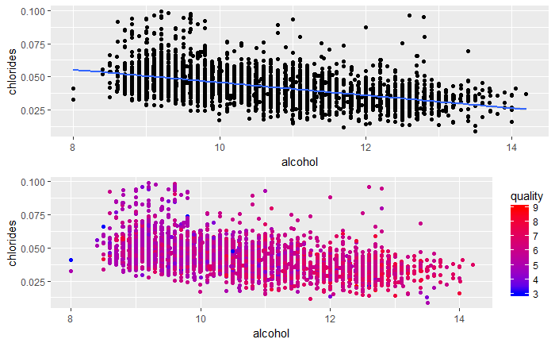

> After removing the outliers from chlorides I created a bivariate plot with alcohol against chlorides and a scale_color_gradient plot in attempt to find an understanding between quality, alcohol, and chlorides. We can see that as alcohol content increases we get a decrease in the amount of chlorides present. This concurs with prior plots when you consider the following: 1. Quality decreases as our chloride value increases 2. Quality increases as our alcohol value increases

> Thus we would expect alcohol and chlorides to have an inverse relationship. Now when we look at our gradient graph we can see that quality increases as we move towards the bottom right of the plot. In other words as we increase alcohol content and decrease chlorides we should get a higher quality wine. It may be helpful to create a variable that represents a ratio of chlorides/alcohol and find the correlation between this new ratio and quality. If we can attain a higher correlation value we may be on the rght track.

```
    Pearson's product-moment correlation

data:  wines$al_chlr and wines$quality
t = -19.052, df = 4896, p-value < 2.2e-16
alternative hypothesis: true correlation is not equal to 0
95 percent confidence interval:
 -0.2885991 -0.2364494
sample estimates:
       cor
-0.2627161
```

> After performing Pearson’s correlation test we can see that my intuition was incorrect. The correlation value came to -0.263 (relatively weak) and was confirmed as a useable value by p-value < 2.2e-16 (much lower than typically accepted 0.05). Thus we must continue to further investigate what factors influence quality.